# R Notebook

# Loading libraries

```r
library(tidyverse)
library(modelr)
library(car)
library(GGally)
library(relaimpo)
```

# Reading in data and exploring

```r
houses <- read.csv("data/kc_house_data.csv")

glimpse(houses)

summary(houses)
```

```r
houses$waterfront
```

# Tidying houses data

```r
houses_clean <- houses %>%
  dplyr::select(-c("id", "date", "sqft_living15", "sqft_lot15", "zipcode")) %>%
  mutate(waterfront = as.numeric(waterfront),
         condition = as.factor(condition),
         grade = as.factor(grade)) %>%
  mutate(renovated = ifelse(yr_renovated > 0, TRUE, FALSE)) %>%
  dplyr::select(-yr_renovated)

glimpse(houses_clean)
```

The “id”, “date”, “sqft_living15”, “sqft_lot15”, “zipcode” variables are deemed not useful in creating a model for price and so are removed.

“waterfront” is converted to numeric and “condition” and “grade” are converted to factors as they ordinal data types.

yr_renovated is mutated to a logical variable called renovated and yr_renovated is then removed.

# Checking for alias variables

```r
alias(lm(price ~ ., data = houses_clean))
```

```
Model :
price ~ bedrooms + bathrooms + sqft_living + sqft_lot + floors +
    waterfront + view + condition + grade + sqft_above + sqft_basement +
    yr_built + lat + long + renovated

Complete :
              (Intercept) bedrooms bathrooms sqft_living sqft_lot floors waterfront view condition2 condition3 condition4 condition5
sqft_basement  0           0        0         1           0        0      0          0    0          0          0          0
              grade3 grade4 grade5 grade6 grade7 grade8 grade9 grade10 grade11 grade12 grade13 sqft_above yr_built lat long renovatedTRUE
sqft_basement  0      0      0      0      0      0      0      0       0       0       0      -1          0        0   0    0
```

“sqft_basement” can be dropped as it is computed the same as “sqft_living” and computed also as not sqft_above - its an alias variable.

## Removing “sqft_basement” as it is alias variable

```r
houses_trim <- houses_clean %>%
  dplyr::select(- sqft_basement)
```

## Rechecking for alias varibales

```r
alias(lm(price ~ ., data = houses_trim))
```

No alias variables detected after removing “sqft_basement”

# Building a regression model

```r
houses_trim_numeric <- houses_trim %>%
  select_if(is.numeric)

houses_trim_nonnumeric <- houses_trim %>%
  select_if(function(x) !is.numeric(x))

houses_trim_nonnumeric$price <- houses_trim$price
```

```r
houses_trim_numeric_plot <- ggpairs(houses_trim_numeric)
ggsave("houses_trim_numeric_plot.pdf")
```

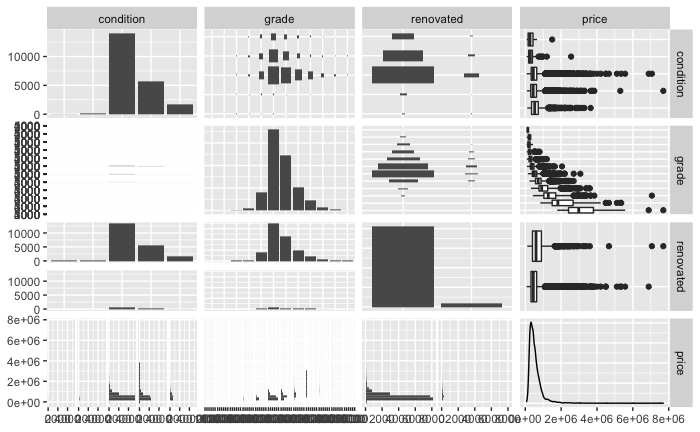

```r
houses_trim_non_numeric_plot <- houses_trim_nonnumeric %>%
  ggpairs()

houses_trim_non_numeric_plot
```

“sqft_living” and "“sqft_above” have strong correlations with price - values of 0.702 and 0.606 respectively

1st effect - “sqft_living”

```r
mod1a <- lm(price ~ sqft_living, data = houses_trim)
summary(mod1a)
```

Residual standard error: 261500 on 21611 degrees of freedom Multiple R-squared: 0.4929

```r
par(mfrow = c(2,2))
plot(mod1a)
```

2nd effect

```r
price_remaining_num_resid <- houses_trim_numeric  %>%
  add_residuals(mod1a) %>%
  dplyr::select(-c(price, sqft_living))
```

```r
price_remaining_num_resid_plot <- ggpairs(price_remaining_num_resid)
ggsave("price_remaining_num_resid_plot.pdf")
```

After subtracting off the systematic variation in price in the houses_trim_numeric, it appears that “lat” has the highest correlation value - 0.379

```r
mod2a <- lm(price ~ sqft_living + lat, data = houses_trim)
summary(mod2a)
```

Residual standard error: 241900 on 21610 degrees of freedom Multiple R-squared: 0.566

```r
par(mfrow = c(2,2))
plot(mod2a)
```

Testing “grade”

```r
mod2b <- lm(price ~ sqft_living + grade, data = houses_trim)
summary(mod2b)
```

Residual standard error: 237500 on 21600 degrees of freedom Multiple R-squared: 0.5817

Both r2 figures for mod2 models are up from mod1a but mod2b has a higher value and lower RSE.

```r
par(mfrow = c(2,2))
plot(mod2b)
```

price ~ sqft_living + grade

## Comparing the two models using ANOVA

```r
anova(mod2a, mod2b)
```

```
Analysis of Variance Table

Model 1: price ~ sqft_living + lat
Model 2: price ~ sqft_living + grade
  Res.Df        RSS Df Sum of Sq      F    Pr(>F)
1  21610 1.2641e+15
2  21600 1.2186e+15 10 4.557e+13 80.776 < 2.2e-16 ***
---
Signif. codes:  0 ‘***’ 0.001 ‘**’ 0.01 ‘*’ 0.05 ‘.’ 0.1 ‘ ’ 1
```

3rd Effect

```r
price_remaining_nonnum_resid <- houses_trim  %>%
  add_residuals(mod2b) %>%
  dplyr::select(-c(price, sqft_living, grade))
```

```r
price_remaining_nonnum_resid_plot <- ggpairs(price_remaining_nonnum_resid)
ggsave("price_remaining_nonnum_resid.pdf")
```

when looking at the other options and result from the anova above, the 3rd predictor should be “lat”

```r
mod3 <- lm(price ~ sqft_living + grade + lat, data = houses_trim)
summary(mod3)
```

```
Call:
lm(formula = price ~ sqft_living + grade + lat, data = houses_trim)

Residuals:
     Min       1Q   Median       3Q      Max
-1528796  -105592   -19877    65573  4599064

Coefficients:
              Estimate Std. Error t value Pr(>|t|)
(Intercept) -3.167e+07  5.600e+05 -56.560  < 2e-16 ***
sqft_living  1.653e+02  2.568e+00  64.377  < 2e-16 ***
grade3       1.442e+05  2.529e+05   0.570  0.56873
grade4       3.540e+04  2.228e+05   0.159  0.87373
grade5       1.285e+04  2.195e+05   0.059  0.95332
grade6       9.338e+03  2.191e+05   0.043  0.96601
grade7       1.415e+04  2.191e+05   0.065  0.94851
grade8       6.418e+04  2.191e+05   0.293  0.76958
grade9       1.752e+05  2.192e+05   0.800  0.42399
grade10      3.556e+05  2.193e+05   1.622  0.10486
grade11      6.300e+05  2.196e+05   2.869  0.00412 **
grade12      1.148e+06  2.207e+05   5.204 1.97e-07 ***
grade13      2.309e+06  2.281e+05  10.126  < 2e-16 ***
lat          6.684e+05  1.084e+04  61.643  < 2e-16 ***
---
Signif. codes:  0 ‘***’ 0.001 ‘**’ 0.01 ‘*’ 0.05 ‘.’ 0.1 ‘ ’ 1

Residual standard error: 219000 on 21599 degrees of freedom
Multiple R-squared:  0.6443,    Adjusted R-squared:  0.644
F-statistic:  3009 on 13 and 21599 DF,  p-value: < 2.2e-16
```

Residual standard error: 219000 on 21599 degrees of freedom Multiple R-squared: 0.6443

RSE down and r-squared up - meaning model is better fit

price ~ sqft_living + grade + lat

#4th effect

```r
mod4 <- lm(price ~ sqft_living + grade + lat + condition, data = houses_trim)
summary(mod4)
```

Residual standard error: 215100 on 21595 degrees of freedom Multiple R-squared: 0.657

RSE down and r-squared up - meaning model is better fit than mod3

Extension

```r
calc.relimp(mod4, type = "lmg", rela = TRUE)

#grade is the most important factor
```